# Telling Stories With Data: Comparing Program Outcomes with ggplot2

Andy Grogan-Kaylor

2022-03-18

# 1 Background

`ggplot2` is a powerful graphing library that can make beautiful graphs. `ggplot2` can also help us to understand ideas of an underlying *“grammar of graphics”*.

However, ggplot can be difficult to learn. I am thinking that one way to better understand `ggplot2` might be to see how this graphing library could be applied to a concrete example of comparing program outcomes.

> In this example, **program** is a *factor* and **mental health at time 2** is *numeric*.

# 2 Load the Simulated Social Service Agency Data

```r
load("social-service-agency.RData") # simulated data
```

> The *mental health* variables are scaled to have an average of 100. Lower numbers indicate lower mental health, while higher numbers indicate higher mental health.

|  | ID | age | gender | race_ethnicity | family_income | program | mental_health_T1 | mental_health_T2 | latitude | longitude |
| --- | --- | --- | --- | --- | --- | --- | --- | --- | --- | --- |
| 1 | 2892 | 23 | Male | African American | 42359.47 | Program B | 95.25 | 106.76 | 42.1621277790243 | -83.5966514429634 |
| 2 | 1971 | 39 | Female | Asian American | 66499.52 | Program C | 82.64 | 96.3 | 42.2922886390713 | -83.8819909476195 |
| 3 | 4728 | 26 | Female | Asian American | 52725.93 | Program C | 80.49 | 98.72 | 42.1385715258813 | -83.7807538220767 |
| 4 | 1020 | 24 | Male | Latinx | 52911.07 | Program D | 93.82 | 91.67 | 42.2362428633003 | -83.6828558629075 |
| 5 | 4429 | 36 | Female | Asian American | 50287.15 | Program C | 83.37 | 99.69 | 42.1769405418916 | -83.638392478015 |
| 6 | 3136 | 33 | Male | African American | 45569.57 | Program C | 75.28 | 92.9 | 42.2103145518908 | -83.7027479830643 |
| 7 | 1651 | 37 | Male | European American | 49527.82 | Program A | 94.68 | 91.63 | 42.1192833938853 | -83.7691783185398 |
| 8 | 4106 | 27 | Male | African American | 44779.89 | Program C | 77.61 | 96.32 | 42.3945649214508 | -83.5122445500111 |
| 9 | 3377 | 35 | Female | African American | 56439.09 | Program B | 98.97 | 109.34 | 42.1710042722833 | -83.7230411173071 |
| 10 | 3119 | 29 | Other Identity | African American | 50130.67 | Program C | 88.43 | 97.66 | 42.3410682235271 | -83.8325830572981 |

[output cut: 443 more lines]

# 3 Load the Libraries

```r
library(ggplot2) # beautiful graphs

library(ggthemes) # beautiful themes
```

# 4 First Approach (x is program; y is mental health)

> There is *a lot of code* below. This is where we are setting up the *grammatical logic* of the graphing approach.

> Devoting some time to setting up the initial logic of the plot will pay dividends in terms of exploring multiple geometries later on.

> Note that I am adding optional `scale_...` and `theme...` arguments just to make the graphs look a little nicer, but these are not an essential part of the code.

```r
myplot1 <- ggplot(clients, # the data I am using
                 aes(x = program, # x is program
                     y = mental_health_T2, # y is mental health
                     color = program, # color is also program
                     fill = program)) + # fill is also program
  labs(y = "mental health at time 2") + # labels
  scale_color_viridis_d() + # beautiful colors
  scale_fill_viridis_d() + # beautiful fills
  theme_minimal() + # minimal theme
  theme(axis.text.x = element_text(size = rel(.75))) # smaller labels
```

# 5 Add Geometries That Show The Average

Now that we have devoted *a lot of code* to setting up the *grammar* of the graph, it is a relatively simple matter to try out different `geom`etries. The `geom`etries show the *average* value.

## 5.1 Bar Chart

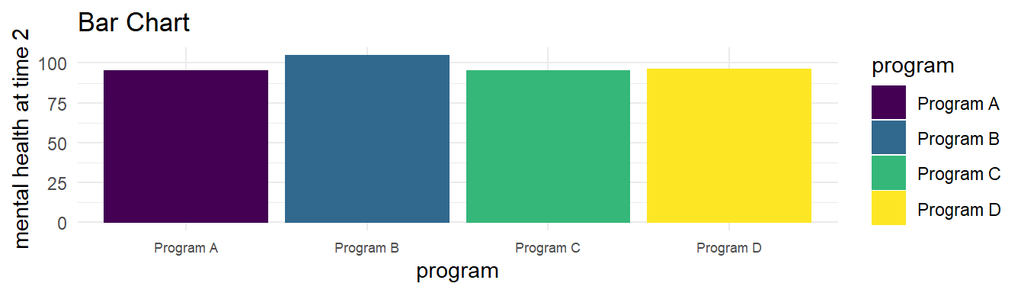

Bar Chart

```r
myplot1 +
  stat_summary(fun = "mean", # summarize at mean
               geom = "bar") + # bar geometry
  labs(title = "Bar Chart")
```

## 5.2 Horizontal Bar Chart

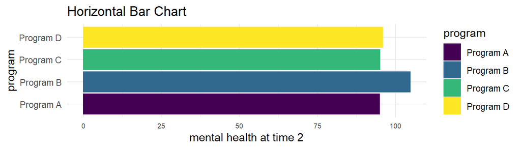

Horizontal Bar Chart

```r
myplot1 +
  stat_summary(fun = "mean", # summarize at mean
               geom = "bar") + # bar geometry
  coord_flip() + # flip coordinates
  labs(title = "Horizontal Bar Chart")
```

## 5.3 Point Chart

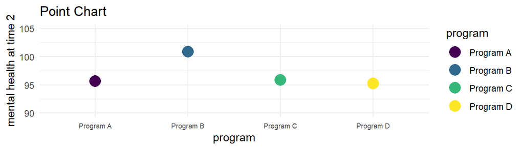

Point Chart

```r
myplot1 +
  stat_summary(fun = "mean", # summarize at mean
               geom = "point", size = 5) + # point geometry
  labs(title = "Point Chart") +
  ylim(90, 105) # manually adjust y limits
```

## 5.4 “Lollipop” Chart

The segments connecting the x axis with the points, require their own `geom`etry that has its own `aes`thetic.

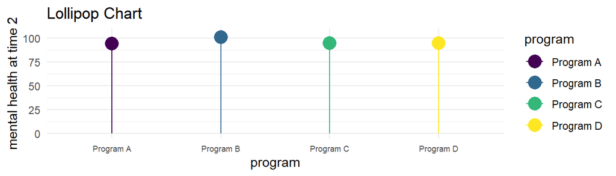

Lollipop Chart

```r
myplot1 +
  stat_summary(fun = "mean",
               geom = "point",
               size = 5) +
  geom_segment(aes(x = program, # x starts at
                   xend = program, # x ends at
                   y = 0, # y starts at
                   yend = mean(mental_health_T2))) + # y ends at
  labs(title = "Lollipop Chart") +
  ylim(0, 105) # manually adjust y limits
```

## 5.5 Line Chart

An extra element of the `aes`thetic is required for lines.

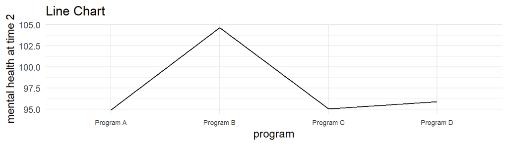

Line Chart

```r
myplot1 +
  stat_summary(aes(group = 1), # line geom needs group aesthetic
               color = "black", # consistent color
               fun = "mean",
               geom = "line") +
  labs(title = "Line Chart")
```

> A line chart is likely *not* an appropriate way to show these program outcomes as a line chart is more appropriate when the x axis represents some kind of *time trend*.

# 6 Add Geometries That Show the Distribution

Now that we have devoted *a lot of code* to setting up the *grammar* of the graph, it is a relatively simple matter to try out different `geom`etries. The `geom`etries show the *distribution* of all values.

## 6.1 Boxplot

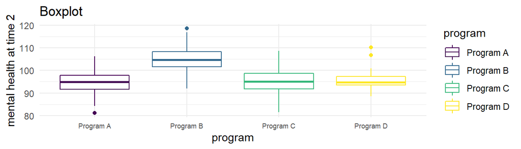

Boxplot

```r
myplot1 +
  geom_boxplot(fill="white") + # boxplot geometry
  labs(title = "Boxplot")
```

## 6.2 Violin Plot

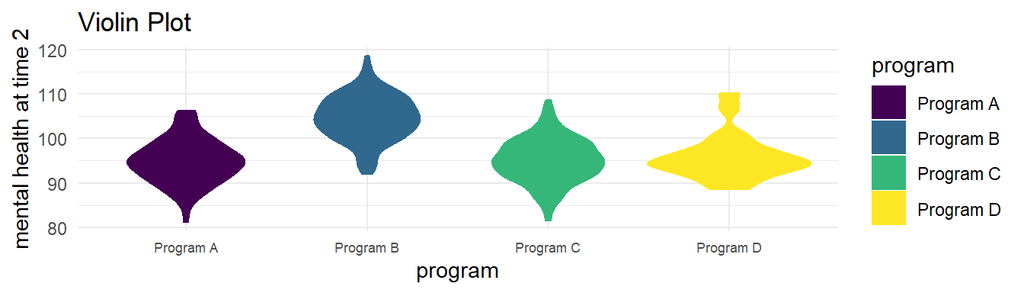

Violin Plot

```r
myplot1 +
  geom_violin() + # violinplot geometry
  labs(title = "Violin Plot")
```

## 6.3 Points

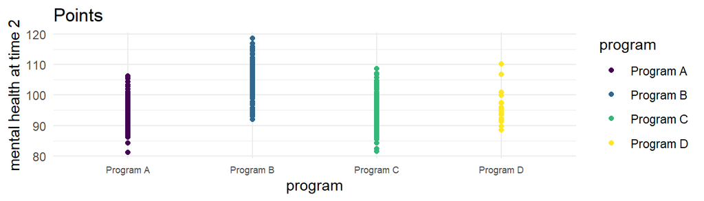

Points

```r
myplot1 +
  geom_point() + # point geometry
  labs(title = "Points")
```

## 6.4 Jittered Points

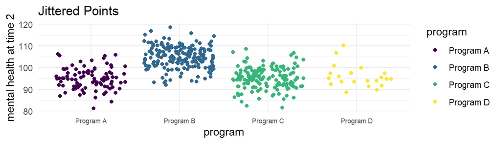

Jittered Points

```r
myplot1 +
  geom_jitter() + # jittered point geometry
  labs(title = "Jittered Points")
```

## 6.5 Beeswarm Plot

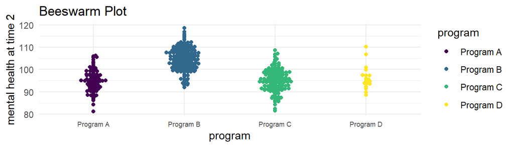

Beeswarm Plot

```r
library(ggbeeswarm) # beeswarm geometry

myplot1 +
  geom_beeswarm() + # beeswarm geometry
  labs(title = "Beeswarm Plot")
```

## 6.6 Dotplots

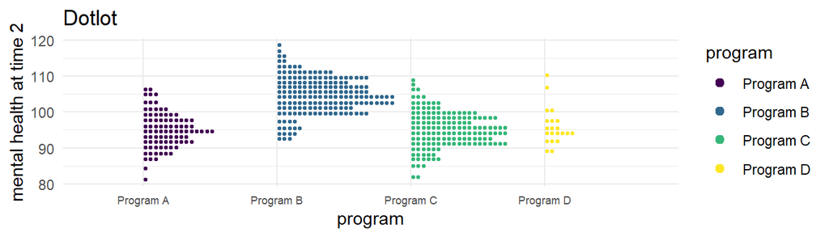

Dotplot

```r
library(ggdist) # dotplot geometry

myplot1 +
  stat_dots() + # dotplot geometry
  labs(title = "Dotlot")
```

# 7 Second Approach (x is mental health; facet wrap on program)

> Again, there is a *lot of code* below. This is where we are setting up the *grammatical logic* of the graphing approach.

```r
myplot2 <- ggplot(clients, # the data I am using
                  aes(x = mental_health_T2, # x is mental health
                      fill = program)) + # fill is program
  facet_wrap(~program) + # facet on this variable
  labs(x = "mental health at time 2") + # labels
  scale_color_viridis_d() + # beautiful colors
  scale_fill_viridis_d() + # beautiful fills
  theme_bw() # bw theme makes facets more clear
```

# 8 Add Geometries

However, now that we have devoted *a lot of code* to setting up the *grammar* of the graph, it is again a relatively simple matter to try out different `geom`etries.

## 8.1 Histogram

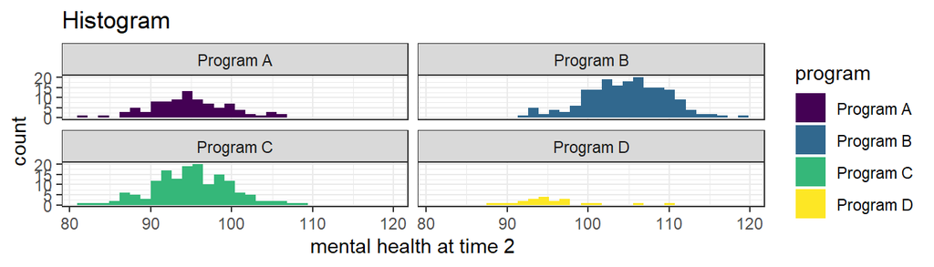

Histogram

```r
myplot2 +
  geom_histogram() + # histogram geometry
  labs(title = "Histogram")
```

## 8.2 Density

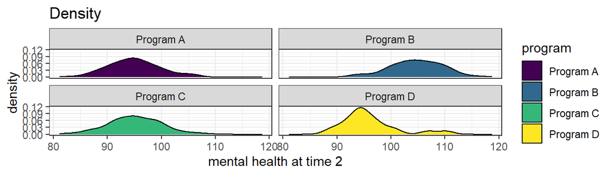

Density

```r
myplot2 +
  geom_density() + # density geometry
  labs(title = "Density")
```

# 9 Third Approach (x is mental health; transparent geometries)

> One last time, there is a *lot of code* below. This is where we are setting up the *grammatical logic* of the graphing approach.

```r
myplot3 <- ggplot(clients, # the data I am using
                  aes(x = mental_health_T2, # x is mental health
                      fill = program)) + # fill is program
  labs(x = "mental health at time 2") + # labels
  scale_color_viridis_d() + # beautiful colors
  scale_fill_viridis_d() + # beautiful fills
  theme_minimal() # minimal theme
```

# 10 Add Geometries

And again, now that we have devoted a lot of code to setting up the *grammar* of the graph, it is again a relatively simple matter to try out different `geom`etries.[^1]

## 10.1 Histogram

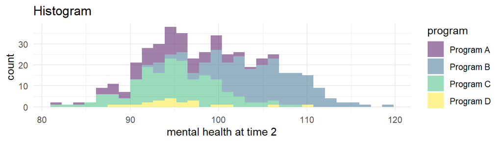

Histogram

```r
myplot3 +
  geom_histogram(alpha = .5) + # histogram geometry (transparent)
  labs(title="Histogram")
```

## 10.2 Density

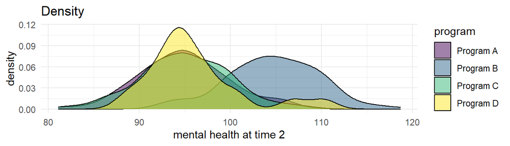

Density

```r
myplot3 +
  geom_density(alpha = .5) + # density geometry (transparent)
  labs(title = "Density")
```

[^1]: It is important to use `(alpha = ...)` to create transparency with these `geom`s.